# Week 3: HW - Visualizing Air Quality Analysis

Jae In Lee

1/29/2023

# Instructions

Use the built-in `airquality` R dataset to visualize the air quality in 1973. Explore the patterns in the data by creating histograms, boxplots, line graphs, heatmaps, and scatterplots.

Load the libraries `ggplot2` and `reshape2` in the setup chunk below.

```r
# Add your library below.

library(ggplot2)
library(reshape2)
```

# Step 1 - Load the Data

We will use the `airquality` dataset that you have as part of your R installation. Read the `airquality` data using the `data.frame()` function and save it as `air`.

```r
# Write your code below.
air <- data.frame(airquality)
```

# Step 2 - Clean the Data

After you load the data, there will be some NA values in the data. You need to figure out what to do about those nasty NAs. Google is your friend. Use Google actively to find a way to get rid of NAs using R.

**HINT:** Find columns that include NA values first (use `colSums()` function, then replace NAs with the mean value of these columns).

Optional: If you want to implement a better approaches to deal with missing data, “multiple imputation” would be where you should go.  
You can check sources like:

- https://gking.harvard.edu/amelia
- http://cran.revolutionanalytics.com/web/packages/mitools/index.html

```r
# Write your code below.

library(mice)
```

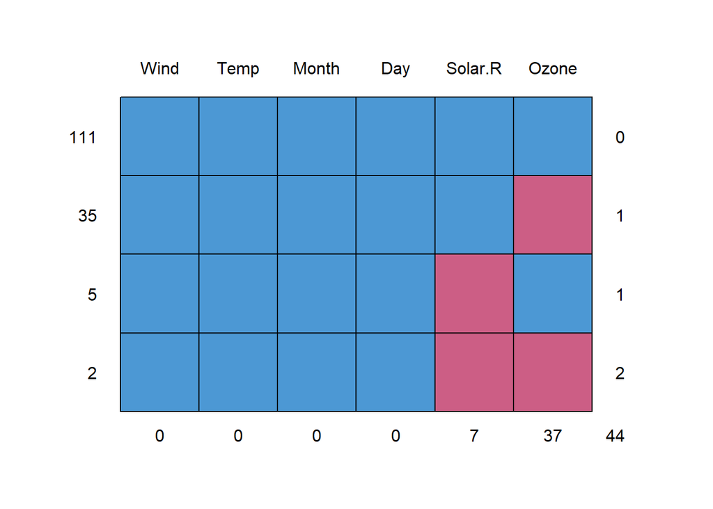

```
##     Wind Temp Month Day Solar.R Ozone
## 111    1    1     1   1       1     1  0
## 35     1    1     1   1       1     0  1
## 5      1    1     1   1       0     1  1
## 2      1    1     1   1       0     0  2
##        0    0     0   0       7    37 44
```

```r
# md.pattern() to check which columns have how many NA values
md.pattern(air)
```

```r
# Use mice function to apply Random Forest (rf) method in order to imputate data
imputed_air <- mice(air, m = 5,  method = "rf")
summary(imputed_air)
```

```
## Class: mids
## Number of multiple imputations:  5
## Imputation methods:
##   Ozone Solar.R    Wind    Temp   Month     Day
##    "rf"    "rf"      ""      ""      ""      ""
## PredictorMatrix:
##         Ozone Solar.R Wind Temp Month Day
## Ozone       0       1    1    1     1   1
## Solar.R     1       0    1    1     1   1
## Wind        1       1    0    1     1   1
## Temp        1       1    1    0     1   1
## Month       1       1    1    1     0   1
## Day         1       1    1    1     1   0
```

```r
# Now, fill in the NA
finished_air <- complete(imputed_air, 1)

# Check for number of NA values in our new dataset
which(is.na(finished_air))
```

```
## integer(0)
```

# Step 3 - Understand the data distribution

Create the following visualizations:

- Histograms for each of the variables
- Boxplot for `Ozone`, and boxplots for different `wind` values (round `wind` to get a good number of “buckets”)

**HINT:** you can create one graph with `Ozone` as X-axis and `Wind` as Y-axis. Also, you can create two graphs (one with `Ozone` values on the Y-axis, and another one with Y-axis value is rounded value of `Wind`). In this case, you need to create a fake grouping variable `(x = factor(0))`.

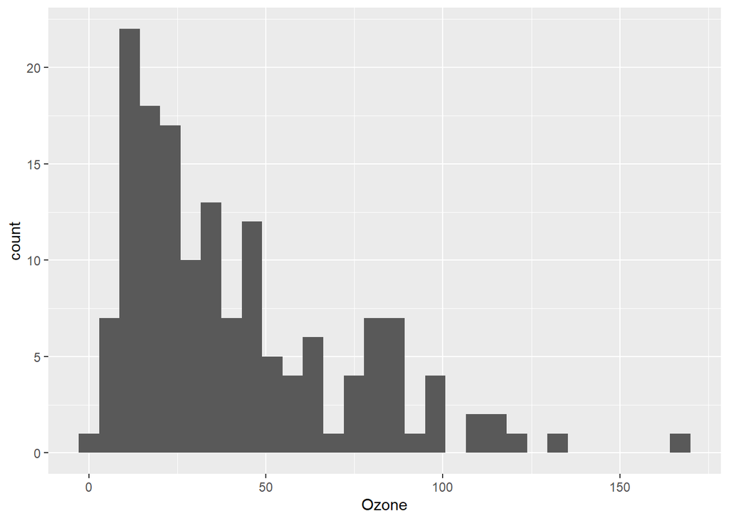

```r
# Write your code below.
ggplot(finished_air, aes(x = Ozone)) +
  geom_histogram()
```

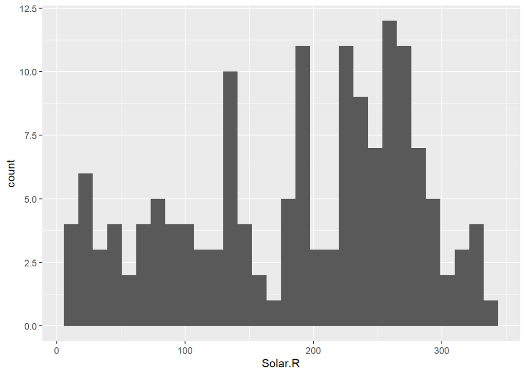

```r
ggplot(finished_air, aes(x = Solar.R)) +
  geom_histogram()
```

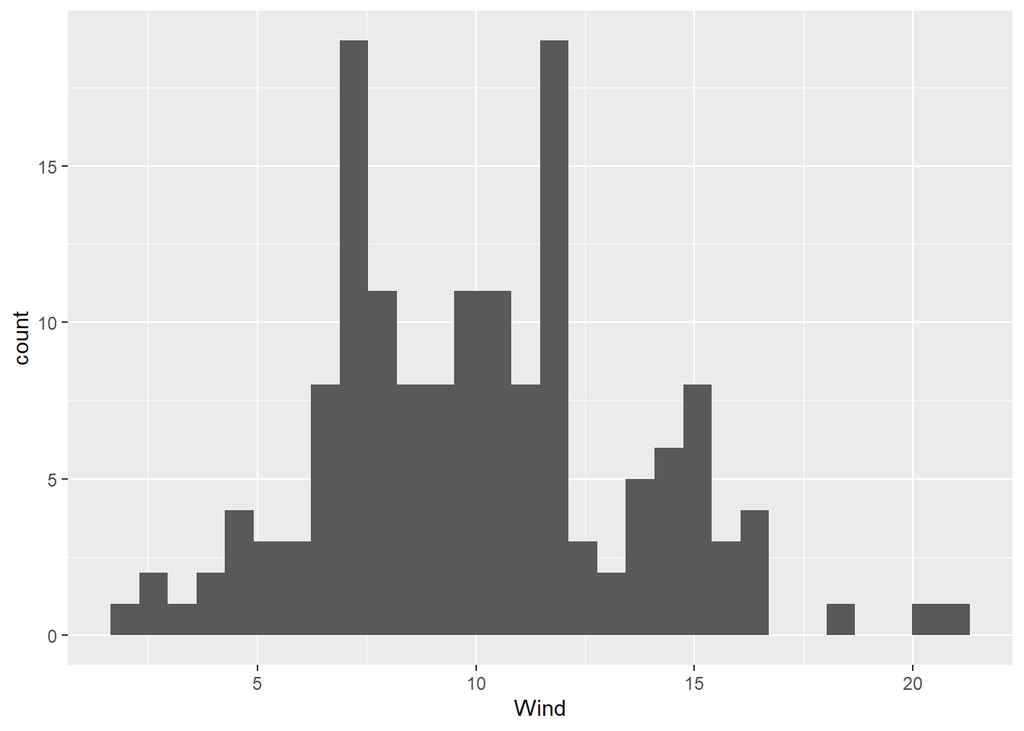

```r
ggplot(finished_air, aes(x = Wind)) +
  geom_histogram()
```

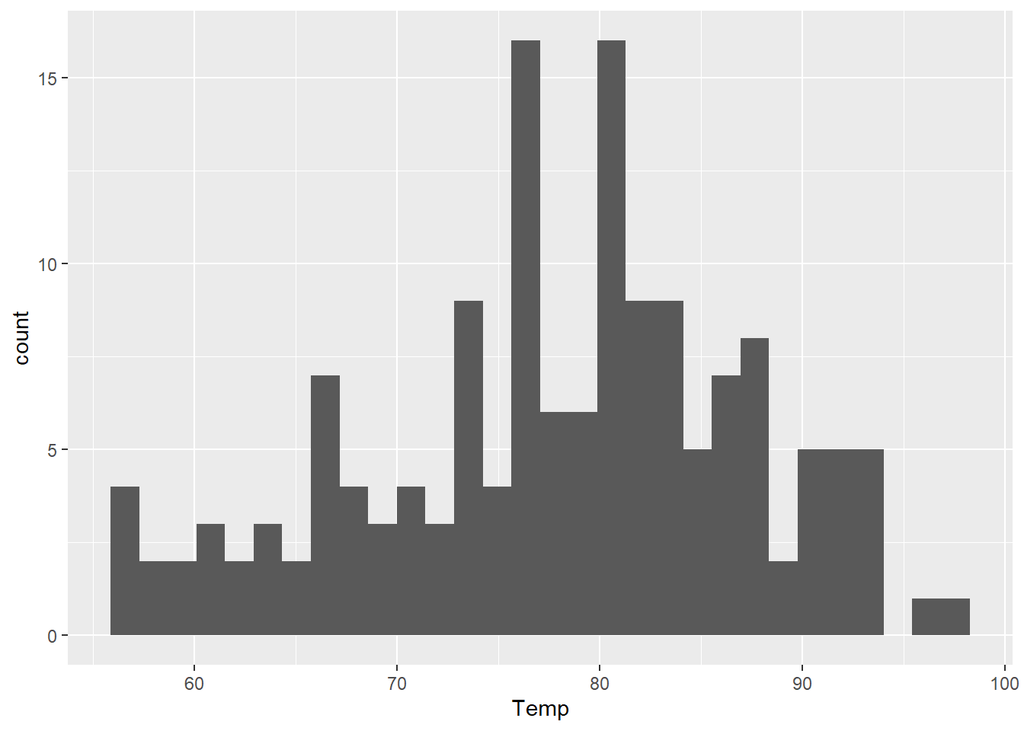

```r
ggplot(finished_air, aes(x = Temp)) +
  geom_histogram()
```

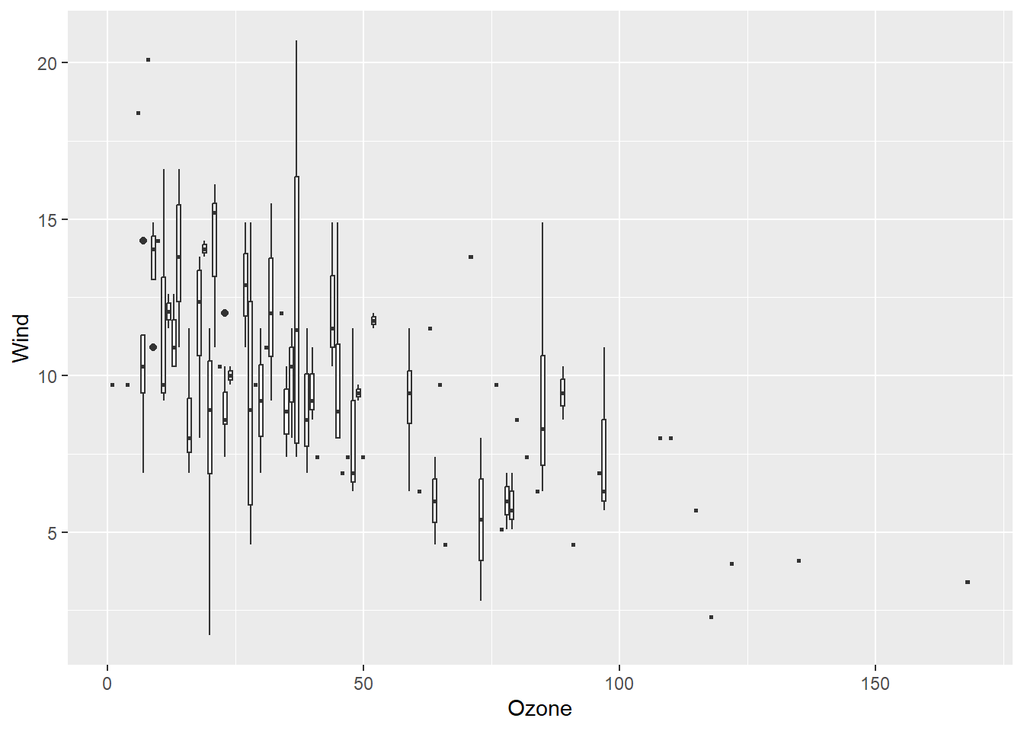

```r
ggplot(finished_air, aes(x = as.numeric(Ozone), y = round(Wind, 1), group = Ozone)) +
  geom_boxplot() +
  labs(x = "Ozone", y = "Wind")
```

```r
#ggplot(finished_air, aes(x = factor(Ozone), y = round(Wind, 1), group = Ozone)) + geom_boxplot()
```

# Step 4 - Explore how the data changes over time

First, create the appropriate dates (this data was from 1973). Then create line charts for `Ozone`, `Temp`, `Wind` and `Solar.R` (one line chart for each, and then one chart with 4 lines, each variable having a different color).

**HINT:**

1. Combine (use `paste()` function) 1973 with the `Month` and `Day` columns, using “/” in between
2. Use `as.Date()` function to transform the value to “Date” format and create a `Date` column to record this value. Use `?as.Date` to find example use of this function.

Note that for the chart with 4 lines, you need to think about how to effectively use the y-axis.

**HINT:** You need to “melt” the columns so that it becomes “long” format. You can either use the `melt()` function or use the `gather()` from the “tidyr” package for the process. Also, compared to other values, the `Wind` values are too small, so they are close to the x-axis. You need to multiply `Wind` by 10 to address this problem.

The correct result should look like this:

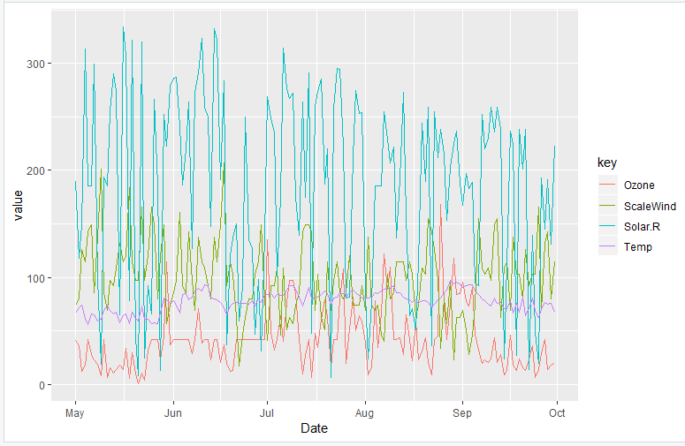

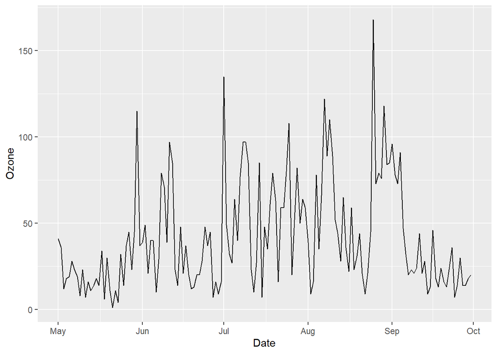

```r
# Write your code below.
# create a list of dates consisted with 1973/m/d format and add to the finshed_air dataset
finished_air$Date <- paste("1973", finished_air$Month, finished_air$Day, sep = "/")
# Transform chr values into date values
finished_air$Date <- as.Date(finished_air$Date, "%Y/%m/%d")
# We can remove Day and Month columns from the dataset now
finished_air <- finished_air[,-5:-6]
# Line charts for `Ozone`, `Temp`, `Wind` and `Solar.R`
ggplot(finished_air, aes(x = Date, y = Ozone)) +
  geom_line()
```

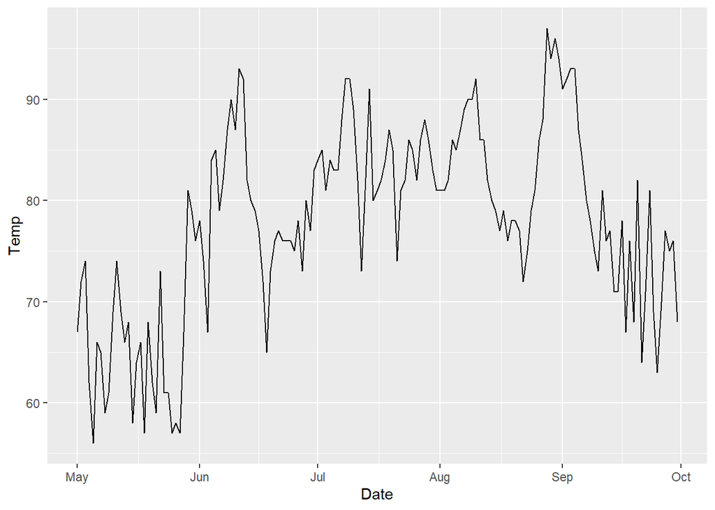

```r
ggplot(finished_air, aes(x = Date, y = Temp)) +
  geom_line()
```

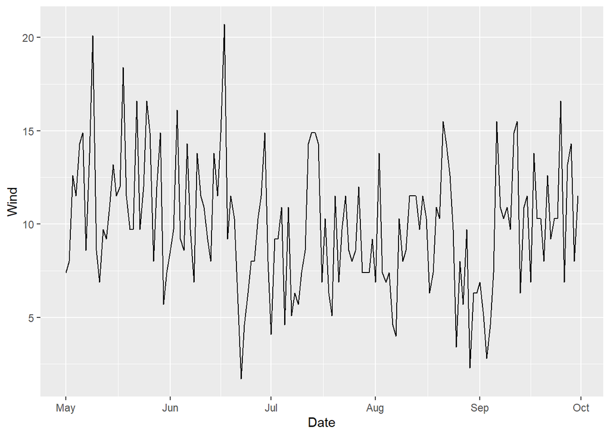

```r
ggplot(finished_air, aes(x = Date, y = Wind)) +
  geom_line()
```

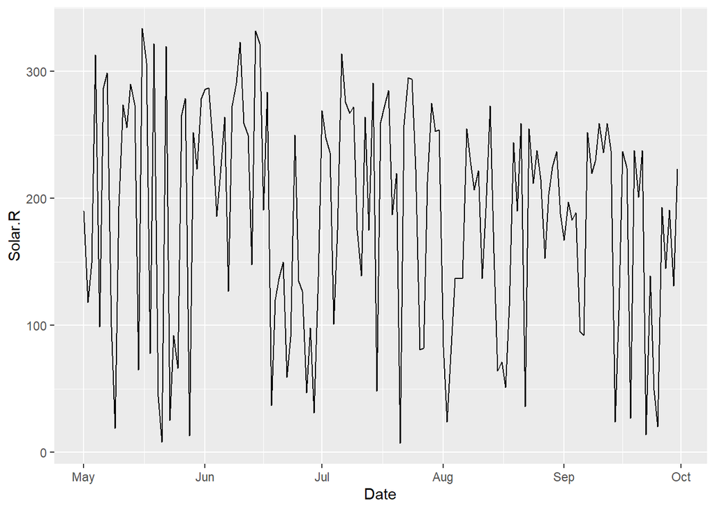

```r
ggplot(finished_air, aes(x = Date, y = Solar.R)) +
  geom_line()
```

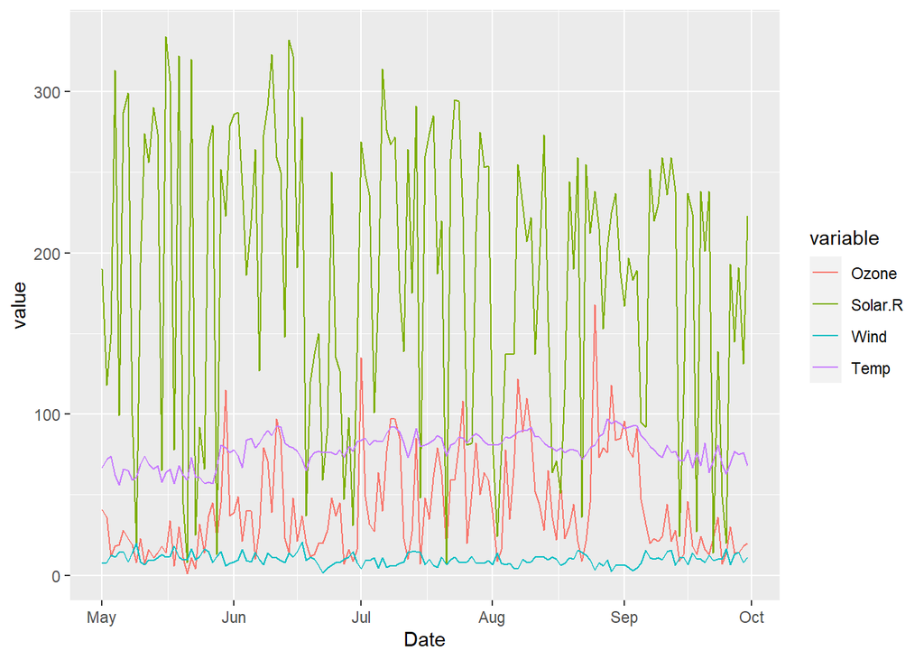

```r
# melt
melted_air <- melt(finished_air, id = "Date")
ggplot(melted_air, aes(x = Date, y = value, color = variable)) +
  geom_line()
```

# Step 5: Look at all the data via a heatmap

Create a heatmap, with each day (using dates) along the x-axis and `Ozone`, `Temp`, `Wind` and `Solar.r` along the y-axis.

Note that you need to figure out how to show the relative change equally across all the variables.

**HINTS:** - You may find this post helpful: - https://learnr.wordpress.com/2010/01/26/ggplot2-quick-heatmap-plotting/ - Melt the original table to make a long format before visualization using `geom_tile()`

Remember, your programming skills will improve as much as you struggle and put effort in them.

The correct result should look like this:

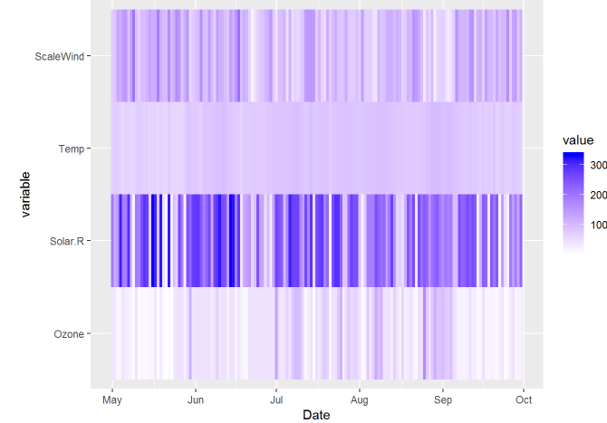

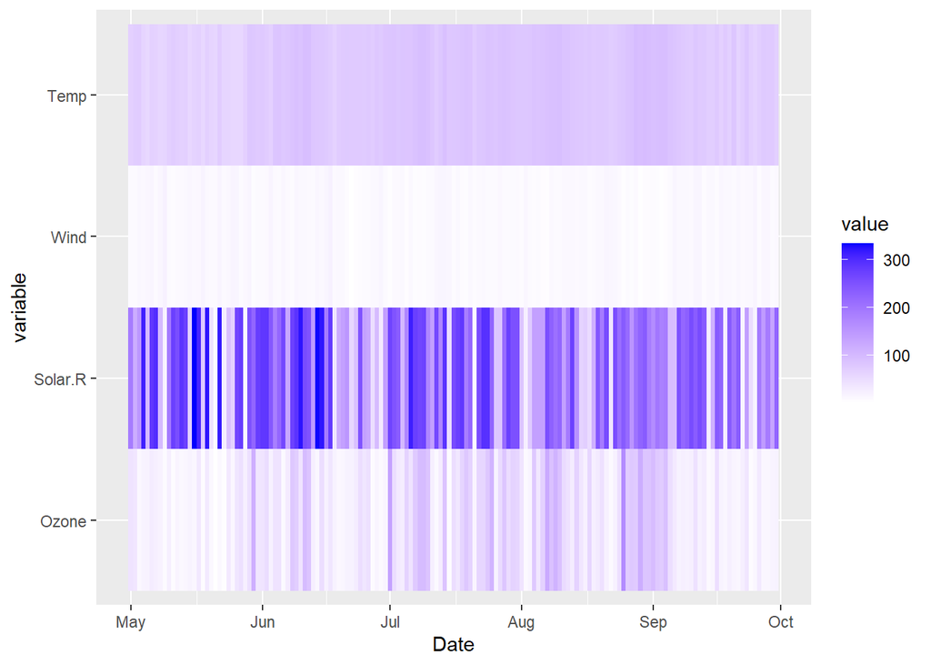

```r
# Write your code below.
ggplot(melted_air, aes(x = Date, y = variable, fill = value)) +
  geom_tile() + scale_fill_gradient(low="white", high="blue")
```

# Step 6: Look at all the data via a scatter chart

Create a scatter chart, with: - the x-axis representing the `Wind` - the y-axis representing the `Temp` - the size of each dot representing the `Ozone` - the color representing `Solar.R`

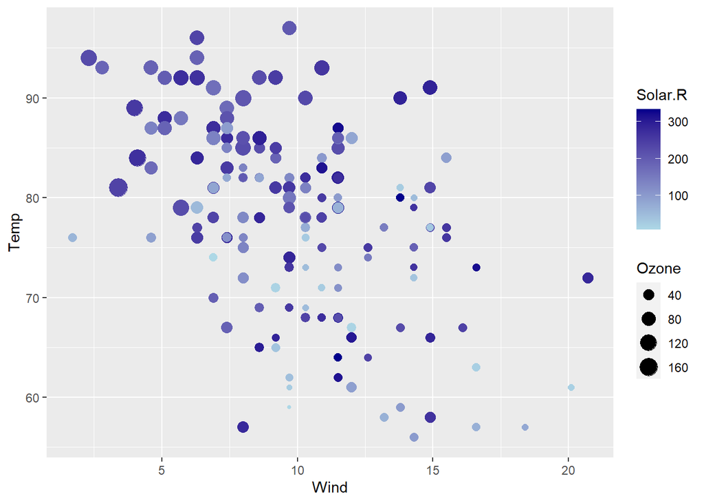

```r
# Write your code below.
ggplot(finished_air, aes(x = Wind, y = Temp)) +
  geom_point(aes(size = Ozone, color = Solar.R)) +
  scale_color_gradient(low = "lightblue", high = "darkblue")
```

# Step 7: Final analysis

### You MUST answer to these questions in your compiled file.

Do you see any patterns after exploring the data?

What was the most useful visualization?

> I think that each visualization conveyed something, while the heatmap, the boxplot and the scatterplot contained particularly interesting patterns. If I were to comment on which of these were least useful, it would be the histograms and maybe even all of the line charts since there is little to no patterns that can be recognized through the human eye.